# ЕГЭ 2018 Вариант 16 EGE 2018 Variant 16

Использованы материалы:

The list of used links and books:

[ЕГЭ 2018. Математика. Профильный уровень. 20 вариантов тестов. Тематическая рабочая тетрадь.](https://drive.google.com/file/d/0B8CJrELbJAyodmtvbV8xcEtZXzA/view)

[SymPy Tutorials](http://nbviewer.jupyter.org/url/www.inp.nsk.su/~grozin/python/sympy.ipynb)

[LaTeX Mathematics](https://en.wikibooks.org/wiki/LaTeX/Mathematics)

[Метод рационализации неравенств (логарифмы)](http://internat.msu.ru/wp-content/uploads/2015/11/Metod-ratsionalizatsii-neravenstv-1.pdf)

```python
%%html
<style>
@import url('https://fonts.googleapis.com/css?family=Roboto&effect=3d|scuffed-steel|static|canvas-print|');
a, h1 h2, h3, h4, div.text_cell_render {font-family: 'Roboto'; text-shadow: 4px 4px 4px #aaa;}

h2, h3, div.output_prompt, div.output_area pre {color: slategray;}
h1, h4, div.input_prompt {color: steelblue;}
a, div.output_subarea {color: darkblue;}

span {text-shadow: 4px 4px 4px #aaa;}

body, div.output_stderr pre{background-color: aliceblue;}
div.output_stderr {background-color: slategray;}
</style>
```

```python
import numpy
import pandas
import math

import matplotlib.pyplot as plt
import matplotlib.patches as pat
from mpl_toolkits.mplot3d import Axes3D
from mpl_toolkits.mplot3d.art3d import Poly3DCollection, Line3DCollection

from __future__ import unicode_literals

import matplotlib
%matplotlib inline
```

```python
import sympy
from sympy import *
from sympy import init_printing
init_printing()
```

```python
answer_dictionary = dict()
```

## Часть 1 Part 1

[figure not shown]

### Задание 1 / Task 1

Пачка сливочного масла стоит 68 рублей. Пенсионерам магазин делает скидку 10%.

Сколько стоит пачка масла для пенсионера?

A pack of butter costs 68 rubles. For pensioners, the store makes a 10% discount.

How much is a pack of butter for a pensioner?

Со скидкой пачка масла будет стоить:

With a discount a pack of butter will cost:

$68 * (100 - 10) / 100 = 61.20 $

### Ответ / Answer: 61,2

```python
answer_dictionary[1]=str(68 * (100 - 10) / 100)
```

[figure not shown]

### Задание 2 / Task 2

На диаграмме показана среднемесячная температура воздуха в Рио-де-Жанейро за каждый месяц 2009 года.

По горизонтали указываются месяцы, по вертикали - температура в градусах Цельсия.

Определите по диаграмме разность между нибольшей и наименьшей среднемесячной температурой в 2009 году.

Ответ дайте в градусах Цельсия.

The diagram shows the average monthly air temperature in Rio de Janeiro for each month of 2009.

Months are indicated horizontally, vertically - temperature in degrees Celsius.

Determine the difference between the smallest and the lowest average monthly temperature in 2009 according to the diagram.

Give the answer in degrees Celsius.

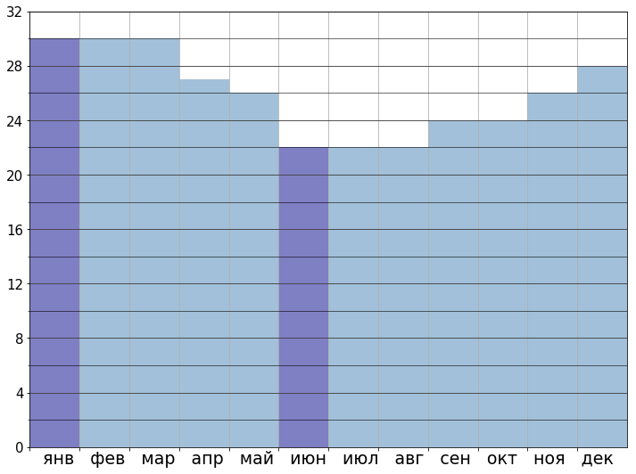

```python
months = ['янв','фев','мар','апр','май','июн','июл','авг','сен','окт','ноя','дек']
df=pandas.DataFrame({'months': months,
                     't': [30,30,30,27,26,22,22,22,24,24,26,28]})
fig,ax = plt.subplots()
df.plot(kind='bar', x='months', ax=ax,
        figsize=(12,9), grid=True,
        color='steelblue', alpha=0.5, align='edge', width=1)

for p in [0,5]:
    ax.patches[p].set_facecolor('darkblue')

plt.xticks(visible=False)
plt.xlabel('   '.join(months), fontsize=19)

ax.set_yticks(numpy.arange(0, 36, 4))
ax.set_yticklabels(['0','4','8','12','16',
                    '20','24','28','32'], fontsize=15)
ax.set_yticks(numpy.arange(0, 36, 2), minor=True)
ax.grid(which='minor', alpha=0.7, color='black')

ax.legend().set_visible(False)

plt.xlim(0,12)
plt.ylim(0,32);
```

Разность между нибольшей и наименьшей среднемесячной температурой равна:

The difference between the smallest and the lowest average monthly temperature is:

$30 - 22 = 8$

### Ответ / Answer: 8

```python
answer_dictionary[2]=str(30-22)
```

[figure not shown]

### Задание 3 / Task 3

Найдите площадь трапеции, вершинами которой являются точки с координатами

Find the area of the trapezoid whose vertices are the points with coordinates

$(1;6), (7;6), (4;1), (2;1)$.

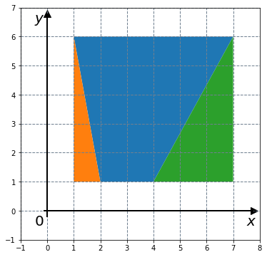

```python
plt.figure(figsize=(6,6))
plt.grid(c='slategray', ls='--', lw=1)

plt.axhline(0, 0.1, 0.97, c='black', lw=2)
plt.axvline(0, 0.1, 0.97, c='black', lw=2)

XY = [[[2,1,7,4], [1,6,6,1]],
      [[1,1,2], [1,6,1]],
      [[4,7,7], [1,6,1]]]
for x,y in XY:
    plt.fill(x,y)

plt.text(7.5,-0.5,r'$x$', fontsize=20)
plt.text(-0.5,6.5,r'$y$', fontsize=20)
plt.text(-0.5,-0.5,r'$0$', fontsize=20)

plt.scatter(0,6.8, marker='^', s=100, c='black')
plt.scatter(7.8,0, marker='>', s=100, c='black')

plt.xlim(-1,8)
plt.ylim(-1,7);
```

$5 * 6 - \large{\frac{5 * 1}{2} - \frac{3 * 5}{2}}$$ = 20$

### Ответ / Answer: 20

```python
answer_dictionary[3]=str(int(5*6 - 5*1/2 - 3*5/2))
```

[figure not shown]

### Задание 4 / Task 4

В группе по английскому языку учатся 10 школьников: Антон, Вадик, Галя, Даша, Игорь, Коля, Люда, Митя, Полина, Ярослав.

В начале урока учительница произвольным образом выбирает ученика, чтобы он отвечал домашнее задание у доски.

Найдите вероятность того, что к доске пойдет мальчик.

There are 10 schoolchildren in the English group: Anton, Vadik, Galya, Dasha, Igor, Kolya, Lyuda, Mitya, Polina, Yaroslav.

At the beginning of the lesson, the teacher arbitrarily chooses a student so that he answers his homework near the chalkboard.

Find the probability that a boy will go to the chalkboard.

В группе из 10 учеников: 6 мальчиков (Антон, Вадик, Игорь, Коля, Митя, Ярослав) и 4 девочки (Галя, Даша, Люда, Полина).

Вероятность случайного события, что отвечать у доски будет мальчик равна 6/10=0.6.

In this group of 10 students: 6 boys (Anton, Vadik, Igor, Kolya, Mitya, Yaroslav) and 4 girls (Galya, Dasha, Lyuda, Polina).

The probability of a random event "a boy will answer near the chalkboard" is 6/10=0.6.

### Ответ / Answer: 0.6

```python
answer_dictionary[4] = str(6/10)
```

[figure not shown]

### Задание 5 / Task 5

Найдите корень уравнения:

Find the root of the equation:

$\large{\bigg(\frac{1}{36}\bigg)^{x-2}}$$ = 6$

Преобразования уравнения: / Equation transformations:

$\large{\bigg(\frac{1}{36}\bigg)^{x - 2}}$$ = 6$

$\large{\bigg(\frac{1}{36}\bigg)^{x - 2}} = \bigg(\frac{1}{36}\bigg)^{-0.5}$

$x - 2 = -0.5$

$x = 1.5$

### Ответ / Answer: 1.5

```python
answer_dictionary[5] = str(1.5)
```

[figure not shown]

### Задание 6 / Task 6

Расстояние от точки пересечения диагоналей ромба до одной из его сторон равно 11, а одна из диагоналей ромба равна 44.

Найдите величину тупого угла ромба. Ответ дайте в градусах.

The distance from the intersection point of the diagonals in the rhombus to one of its sides is 11, and one of the rhombus diagonals is 44.

Find the value of the obtuse angle in the rhombus. Give the answer in degrees.

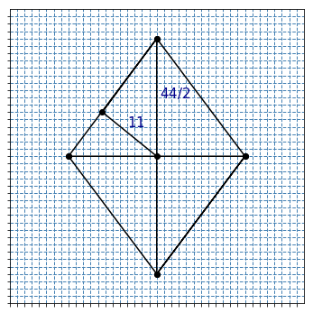

```python
f = plt.figure(figsize=(6,6))
ax = f.add_subplot(1, 1, 1, aspect=1)
ax.grid(c='steelblue', ls='--', lw=1)

ax.plot([-6,0,6,0,-6,6,0,0,-3.7,0],
        [0,-8,0,8,0,0,-8,8,3,0],
        '-o', c='black')

plt.text(-2,2,r'$11$',color='darkblue',fontsize=15)
plt.text(0.2,4,r'$44/2$',color='darkblue',fontsize=15)

plt.xlim(-10,10)
plt.ylim(-10,10)
plt.xticks(numpy.arange(-10, 10, step=0.5), visible=False)
plt.yticks(numpy.arange(-10, 10, step=0.5), visible=False);
```

Половина дагонали ромба равна 44/2 = 22.

Синус половины острого угла ромба равен 11 / 22 = 0.5. $\implies$ Острый угол ромба равен $2 * 30^o = 60^o$.

Любой ромб является параллелограммом. $\implies$ Тупой угол ромба равен $180^o - 60^o = 120^o$.

The half of the rhombus's dagonal is 44/2 = 22.

The sine of the half of the acute angle in the rhombus is 11/22 = 0.5. $\implies$ The acute angle of the rhombus is $2 * 30^o = 60^o$.

Any rhombus is a parallelogram. $\implies$ The obtuse angle of the rhombus is $ 180 ^ o - 60 ^ o = 120 ^ o $.

### Ответ / Answer: 120

```python
answer_dictionary[6] = str(120)
```

[figure not shown]

### Задание 7 / Task 7

На рисунке изображен график функции y = f(x) и десять точек на оси абсцисс:

The figure shows the graph of the function y = f (x) and ten points on the abscissa:

$x_1,x_2,x_3,x_4,x_5,x_6,x_7,x_8,x_9,x_{10}$

В скольких из этих точек производная $f'(x)$ функции $f(x)$ положительна?

In how many of these points the derivative $f'(x)$ of the function $f(x)$ is positive?

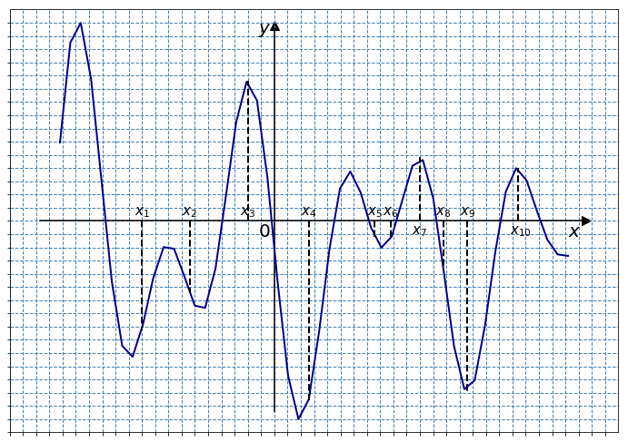

```python
f = plt.figure(figsize=(12,9))
ax = f.add_subplot(1, 1, 1, aspect=1)
ax.grid(c='steelblue', ls='--', lw=1)
ax.axhline(0, 0.05, 0.95, c='black')
ax.axvline(0, 0.05, 0.95, c='black')

def f(x,a=7,b=0.4,c=1.5,d=3.1,e=-1):
    exp = (math.pow(x, 2) + math.pow(x, 5)) * (-0.1)**5
    return a * math.exp(exp) * math.cos(b*x+d) * math.sin(c*x)+e

x = numpy.linspace(-8.1,11.1)
y = [f(el) for el in x]
ax.plot(x, y, c='darkblue', lw=2)

vl = [-5,-3.2,-1,1.3,3.8,4.4,5.5,6.4,7.3,9.2]
for v in vl:
    ax.plot([v,v], [0,f(v)], lw=2, ls='--', c='black')

v = numpy.array([vl, [0.2,0.2,0.2,0.2,0.2,0.2,-0.5,0.2,0.2,-0.5],
                 [r'$x_1$',r'$x_2$',r'$x_3$',r'$x_4$',r'$x_5$',
                  r'$x_6$',r'$x_7$',r'$x_8$',r'$x_9$',r'$x_{10}$']])
for i in range(10):
    plt.text(float(v[0][i])-0.3,float(v[1][i]),v[2][i],fontsize=15)

plt.text(11.1,-0.6,r'$x$', fontsize=20)
plt.text(-0.6,7.1,r'$y$', fontsize=20)
ax.scatter(0,7.4, marker='^', s=100, c='black')
ax.scatter(11.8,0, marker='>', s=100, c='black')
plt.text(-0.6,-0.6,r'$0$', fontsize=20)

plt.xlim(-10,13)
plt.ylim(-8,8)
plt.xticks(numpy.arange(-10,13, step=0.5), visible=False)
plt.yticks(numpy.arange(-8,8, step=0.5), visible=False);
```

Производная положительна на тех интервалах, где функция возрастает.

The derivative is positive in those intervals where the function increases.

$x_1,x_4,x_6$

### Ответ / Answer: 3

```python
answer_dictionary[7] = str(3)
```

[figure not shown]

### Задание 8 / Task 8

Площадь полной поверхности конуса равна 84.

Параллельно основанию конуса проведено сечение, делящее высоту пополам.

Найдите площадь полной поверхности отсеченного конуса.

The total cone surface area is equal to 84.

In parallel with the base of the cone, a section is made dividing the height in half.

Find the total area of the cut off cone.

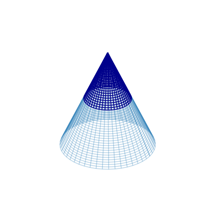

```python
f = plt.figure(figsize=(7,7))
ax = f.add_subplot(111,projection='3d')

theta = numpy.linspace(0,2*numpy.pi,50)
r = numpy.linspace(0,4,50)
T, R = numpy.meshgrid(theta, r)

X = R * numpy.cos(T)
Y = R * numpy.sin(T)
Z = - numpy.sqrt(X**2 + Y**2)

ax.plot_wireframe(X, Y, Z, alpha=0.3)
Z[Z<-2] = numpy.nan
ax.plot_wireframe(X, Y, Z, colors='darkblue')

plt.axis('off');
```

Исходный конус подобен отсеченному с коэффициентом 2.

Площади полных поверхности подобных тел относятся как квадраты коэффициента подобия.

The initial cone is similar to the cut off cone with the coefficient 2.

The areas of the total surfaces of similar solids are in the ratio of a square of the similarity coefficient.

$S_1 / S_2 = 2^2 \implies S_2 = S_1 / 4 = 84 / 4 = 21$

### Ответ / Answer: 21

```python
answer_dictionary[8] = str(21)
```

[figure not shown]

### Задание 9 / Task 9

Найдите значение выражения

Find the value of the expression

$(558^2 - 23^2):581$

$(558^2 - 23^2) / 581 = (558 + 23) * (558 - 23) / 581 = 581 * 535 / 581 = 535$

### Ответ / Answer: 535

```python
answer_dictionary[9] = str(535)
```

[figure not shown]

### Задание 10 / Task 10

Для обогрева помещения, температура в котором равна $T_п = 20^o C$, через радиатор отопления пропускают горячую воду температурой $T_в = 88^o C$.

Расход проходящей через трубу воды $m = 0.4 кг/с$. Проходя по трубе расстояние $x (м)$, вода охлаждается до температуры $T(^o)$, причем

$x = \alpha * \large{\frac{c * m}{\gamma}}$ $ * \log_2{\large{\frac{T_в - T_п}{T - T_п}}}$(м), где $c = 4200 \large{\frac{Дж}{кг * ^oC}}$ - теплоемкость воды, $\gamma = 63 \large{\frac{Вт}{м * ^oC}}$ - коэффициент теплообмена, а $\alpha = 1.2$ - постоянная.

До какой температуры (в градусах Цельсия) охладится вода, если длина трубы равна 64 м?

For heating the room, the temperature in which is equal to $T_п = 20^o C$, hot water with the temperature $T_в = 88^o C$ is passed through the radiator.

The flow of water passing through the pipe is $m = 0.4 \ kg / s$. Passing along the pipe the distance $x \ (m)$, the water is cooled to the temperature $T \ (^o)$, and

$x = \alpha * \large{\frac{c * m}{\gamma}}$ $ * \log_2{\large{\frac{T_в - T_п}{T - T_п}}}$(m), where $c = 4200 \large {\frac {J} {kg * ^oC}}$ is the heat capacity of water, $\gamma = 63\large{\frac{W}{m * ^oC}}$ is the heat transfer coefficient, and $\alpha = 1.2$ is a constant.

To what temperature (in degrees Celsius) water will cool, if the length of the pipe is 64 m?

Подставим имеющиеся данные в уравнение.

Let's substitute the available data in the equation.

$64 = 1.2 * \large{\frac{4200 * 0.4}{63}} $$ * \log_2{\large{\frac{88 - 20}{T - 20}}}$

$64 = 32 * \log_2{\large{\frac{68}{T - 20}}}$

$2 = \log_2{\large{\frac{68}{T - 20}}}$

$\log_2 4 = \log_2{\large{\frac{68}{T - 20}}}$

$4 = {\large{\frac{68}{T - 20}}}$

$4 * T - 80 = 68$

$T = 37$

### Ответ / Answer: 37

```python
answer_dictionary[10] = str(37)
```

[figure not shown]

### Задание 11 / Task 11

В четверг акции компании подорожали на некоторое число процентов, а в пятницу подешевели на то же самое число процентов.

В результате они стали стоить на 9 % дешевле, чем при открытии торгов в четверг.

На сколько процентов подорожали акции компании в четверг?

On Thursday, the company's shares rose in price by a certain percentage, and on Friday, fell by the same number of percent.

As a result, they cost 9% cheaper than at opening trades on Thursday.

By what percentage did the company's shares go up on Thursday?

Примем за 1 начальную стоимость акций и обозначим x - искомое количество процентов (в долях).

Например, доля 0.1 от стоимости составляет 10%.

Let's use 1 as an initial share price and denote x - the required amount of interest (in proportion).

For example, the proportion 0.1 from the cost is 10%.

$(1 - x) * (1 + x) = 1 - 0.09$

$1 - x^2 = 0.91$

$x^2 = 0.09$

$x = 0.3$

$0.3 * 100 \% = 30 \%$

### Ответ / Answer: 30

```python
answer_dictionary[11] = str(30)
```

[figure not shown]

### Задание 12 / Task 12

Найдите наибольшее значение функции

Find the largest value of the function

$y = - \large{\frac{2}{3}}$$\ * x * \sqrt{x} + 3 * x + 19$

на отрезке $[8;21]$.

on the interval $[8;21]$.

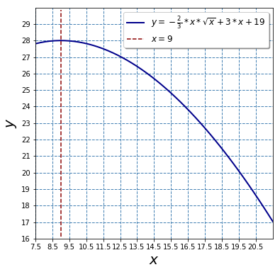

```python
f = plt.figure(figsize=(6,6))
ax = f.add_subplot(1, 1, 1)
ax.grid(c='steelblue', ls='--', lw=1)

def f(x):
    return -2 / 3 * x ** 1.5 + 3 * x + 19

x = numpy.linspace(7.5,21.5)
y = [f(el) for el in x]
ax.plot(x, y, c='darkblue', lw=2,
        label=r'$y = - \frac{2}{3} * x * \sqrt{x} + 3 * x + 19$')

ax.axvline(9, 0.01, 0.99, c='darkred',
           ls='--',label=r'$x=9$')

plt.xlim(7.5,21.5)
plt.ylim(16,30)
plt.xticks(numpy.arange(7.5,21.5, step=1))
plt.yticks(numpy.arange(16,30, step=1))

plt.xlabel(r'$x$', fontsize=20)
plt.ylabel(r'$y$', fontsize=20)
plt.legend(fontsize=12, shadow=True, loc=1);
```

```python
x = Symbol('x')
y = -2 / 3 * x ** 1.5 + 3 * x + 19
```

```python
# производная | the first derivative
diff(y,x)
```

$$- 1.0 x^{0.5} + 3$$

```python
# производная равна нулю ∣ the first derivative is 0
solve(diff(y,x),x)
```

$$\left [ 9.0\right ]$$

```python
# вторая производная / the second derivative
diff(diff(y,x),x)
```

$$- \frac{0.5}{x^{0.5}}$$

```python
# y''(9) < 0 => max
diff(diff(y,x),x).subs({x:9})
```

$$-0.166666666666667$$

```python
# y(9)
y.subs({x:9})
```

$$28.0$$

### Ответ / Answer: 28

```python
answer_dictionary[12] = str(int(y.subs({x:9})))
```

## Часть 2 Part 2

[figure not shown]

### Задание 13 / Task 13

a) Найдите корень уравнения:

a) Find the root of the equation:

$6 * \sin^2 x + 7 * \cos \ x - 7 = 0$.

б) Найдите все корни этого уравнения, принадлежащие промежутку

b) Find all the roots of this equation that belong to the interval

$[-3 * \pi; -\pi]$.

a)

$6 * \sin^2 x + 7 * \cos \ x - 7 = 0$

$6 * (1 - \cos^2 x) + 7 * \cos \ x - 7 = 0$

$6 * \cos^2 x - 7 * \cos \ x + 1 = 0$

$D = 49 - 4 * 6 * 1 = 25$

$cos \ x = \large{\frac{7 \pm \sqrt{25}}{2 * 6}}$

$cos \ x = 1$$ \; \lor \; cos \ x = \large{\frac{1}{6}}$

$x = \pm 2 * \pi* n \; \lor \; x = \pm \arccos \frac{1}{6} \pm 2 * \pi * k; \; n,k \in \mathbb{N}$

б)

$-2 * \pi; \; -2 * \pi + arccos\frac{1}{6}$

### Ответ / Answer:

#### a) $\pm 2 * \pi* n \; \lor \; \pm \arccos \frac{1}{6} \pm 2 * \pi * k; \; n,k \in \mathbb{N}$;

#### б) $-2 * \pi ; \; -2 * \pi + arccos\frac{1}{6}$

```python
# check the decision method
x = Symbol('x')
g = 6 * (cos(x)) ** 2  - 7 * cos(x) + 1
```

```python
g
```

$$6 \cos^{2}{\left (x \right )} - 7 \cos{\left (x \right )} + 1$$

```python
solve(g,x)
```

$$\left [ 0, \quad 2 \pi, \quad - \operatorname{acos}{\left (\frac{1}{6} \right )} + 2 \pi, \quad \operatorname{acos}{\left (\frac{1}{6} \right )}\right ]$$

```python
h = 6 * (sin(x)) ** 2  + 7 * cos(x) - 7
```

```python
h
```

$$6 \sin^{2}{\left (x \right )} + 7 \cos{\left (x \right )} - 7$$

```python
# :)
solve(h,x)
```

$$\left [ 0, \quad - 2 \operatorname{atan}{\left (\frac{\sqrt{35}}{7} \right )}, \quad 2 \operatorname{atan}{\left (\frac{\sqrt{35}}{7} \right )}\right ]$$

```python
N(-3 * pi), N(-solve(g,x)[1]), N(-solve(g,x)[2]), N(-pi)
```

$$\left ( -9.42477796076938, \quad -6.28318530717959, \quad -4.87983705960438, \quad -3.14159265358979\right )$$

```python
answer_dictionary[13] = 'a)±2πn ∨ ±arccos(1/6)±2πk; n,k∈ℕ; б)−2π;−2π+arccos(1/6)'
```

[figure not shown]

### Задание 14 / Task 14

В правильной треугольной призме $ABCA_1B_1C_1$ все рёбра равны 1.

а) Постройте прямую пересечения плоскости $ABB_1$ и плоскости, проходящей через точки $C, C_1$ перпендикулярно плоскости $ACC_1$.

б) Найдите косинус угла между прямыми $AB_1$ и $BC_1$.

In the regular triangular prism $ABCA_1B_1C_1$, all edges are equal to 1.

a) Construct the intersection of the plane $ABB_1$ and the plane passing through points $C, C_1$ perpendicular to the plane $ACC_1$.

b) Find the cosine of the angle between the lines $AB_1$ and $BC_1$.

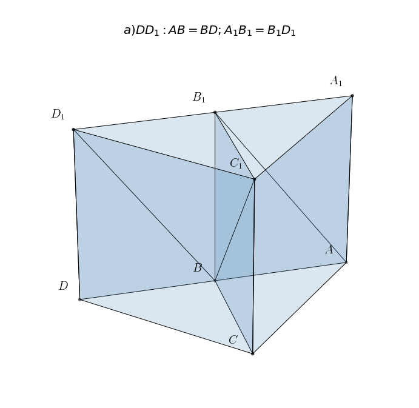

```python
f = plt.figure(figsize=(12,12))
ax = f.add_subplot(111, projection='3d')

matplotlib.rcParams['text.usetex'] = True
matplotlib.rcParams['text.latex.unicode'] = True

v = numpy.array([[0,0,0], [5,4,0], [10,0,0], [10,8,0],
                 [0,0,5], [5,4,5], [10,0,5], [10,8,5] ])
ax.scatter3D(v[:, 0], v[:, 1], v[:, 2], color='black')

letters = [r'$D$', r'$B$',r'$C$',r'$A$',
           r'$D_1$',r'$B_1$',r'$C_1$',r'$A_1$']
verts = [ [v[0],v[3],v[7],v[4]],
          [v[1],v[5],v[6],v[2]],
          [v[0],v[4],v[6],v[2]],
          [v[2],v[3],v[7],v[6]],
          [v[3],v[5]],[v[1],v[6]],[v[1],v[4]]]

for i in range(8):
    ax.text(v[i][0]-1.3,v[i][1],v[i][2]+0.1,
            letters[i],fontsize=20)

lines = Poly3DCollection(verts, lw=1, alpha=0.2,
                         edgecolors='black', facecolor='none')
lines.set_facecolor('steelblue')

ax.add_collection3d(lines)
plt.title(r'$a) DD_1: AB = BD; A_1B_1 = B_1D_1$',fontsize=20)
plt.axis('off');
```

a)

На прямых $AB, A_1B_1$ отметим точки $D, D_1$: $AB = BD, A_1B_1 = B_1D_1$

$\implies DD_1$ принадлежит плоскости $ABB_1$.

По условию $\triangle ABC: AB = AC = BC, \angle ABC = \angle ACB = \angle BAC = 60^o$

По построению $\triangle BCD: \angle DBC = 180^o - \angle ABC = 120^o, DB = BC \implies \angle BDC = \angle BCD = (180^o - \angle DBC) / 2 = 30^o$.

$\angle DCA = \angle BCD + \angle ACB = 60^o + 30^o = 90^o$.

$CD \bot AC, C_1D_1 \bot A_1C_1 \implies DCC_1$ перпендикулярна плоскости $ACC_1$.

$DD_1$ принадлежит плоскости $DCC_1 \implies DCC_1 \cap ABB_1 = DD_1$

On the lines $AB, A_1B_1$ we mark the points $D, D_1$: $AB = BD, A_1B_1 = B_1D_1$

$\implies DD_1$ belongs to the plane $ABB_1$.

By the task conditions $\triangle ABC: AB = AC = BC, \angle ABC = \angle ACB = \angle BAC = 60^o$.

By construction, $\triangle BCD: \angle DBC = 180^o - \angle ABC = 120^o, DB = BC \implies \angle BDC = \angle BCD = (180^o - \angle DBC) / 2 = 30^o$.

$\angle DCA = \angle BCD + \angle ACB = 60^o + 30^o = 90^o$.

$CD \bot AC, C_1D_1 \bot A_1C_1 \implies DCC_1$ is perpendicular to the plane $ACC_1$.

$DD_1$ belongs to the plane $DCC_1 \implies DCC_1 \cap ABB_1 = DD_1$.

б)

$BD_1 = AB_1, BD_1 \| AB_1 \implies \angle C_1BD_1$ - искомый.

$BD_1 = AB_1, BD_1 \| AB_1 \implies \angle C_1BD_1$ should be found.

$BCC_1B_1, BB1D_1D$ - квадраты со стороной 1.

$BCC_1B_1, BB1D_1D$ are squares with side 1.

$\implies BC_1 = BD_1 = \sqrt{2}$.

$\triangle A_1C_1D_1: A_1D_1 = 2 * A_1B_1 = 2, A_1C_1 = 1, C_1D_1 = \sqrt{2^2 - 1^2} = \sqrt{3}$.

По теореме косинусов

By the cosine theorem

$\cos \angle C_1BD_1 = \large{\frac{2 * (\sqrt{2})^2 - (\sqrt{3})^2}{2 * (\sqrt{2})^2} = \frac{1}{4}}$.

### Ответ / Answer: б) $\frac{1}{4}$

```python
answer_dictionary[14] ='б) 1/4'
```

[figure not shown]

### Задание 15 / Task 15

Решите неравенство:

Solve the inequality:

$2^x + 3 * 2^{-x} \leq 4$

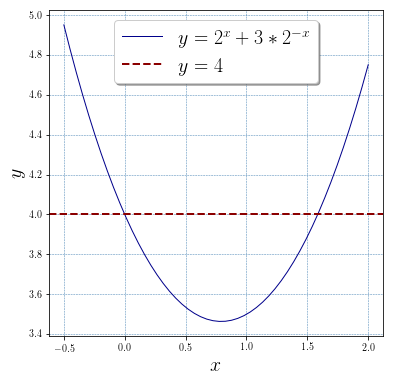

```python
plt.figure(figsize=(6,6))

x = numpy.linspace(-0.5,2)
y = [2 ** el + 3 * 2 ** (-el) for el in x]
plt.plot(x, y, c='darkblue', lw=1,
         label=r'$y = 2^x + 3 * 2^{-x}$')
plt.axhline(4, c='darkred', ls='--', lw=2,label=r'$y = 4$')

plt.grid(c='steelblue', ls='--', lw=0.5)
plt.xlabel(r'$x$', fontsize=20)
plt.ylabel(r'$y$', fontsize=20)
plt.legend(fontsize=20, shadow=True);
```

$2^x + 3 * 2^{-x} \leq 4$

$(2^x)^2 - 4 * 2^ x + 3 \leq 0$

$D = 4^2 - 4 * 3 = 4$

$(2^x - 1) * (2^x - 3) \leq 0$

$1 \leq 2^x \leq 3$

$2^0 \leq 2^x \leq 2^{log_2{3}}$

$0 \leq x \leq log_2{3}$

### Ответ / Answer: $[0;log_2{3}]$

```python
answer_dictionary[15] ='[0;log2(3)]'
```

[figure not shown]

### Задание 16 / Task 16

В параллелограмме $ABCD$ известно, что $AB = 1$, $BC = 2$, $\angle A = 60^o$.

На сторонах $AB$ и $BC$ как на основаниях построены вне параллелограмма равнобедренные треугольники с углами $120^o$ при вершинах.

а) Докажите, что прямая, соединяющая вершины этих треугольников, проходит через точку $B$.

б) Найдите расстояние между этими вершинами.

In the parallelogram $ABCD$, it is known that $AB = 1$, $BC = 2$, $\angle A = 60^o$.

On the sides $AB$ and $BC$, as on the bases, isosceles triangles with angles $120^o$ at vertices are constructed outside the parallelogram.

a) Prove that the line connecting the vertices of these triangles passes through point $B$.

b) Find the distance between these vertices.

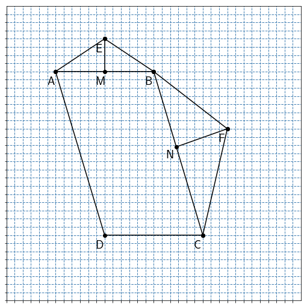

```python
f = plt.figure(figsize=(9,9))
ax = f.add_subplot(1, 1, 1, aspect=1)
ax.grid(c='steelblue', ls='--', lw=1)

x = [-6,-3,3,4.5,0,-3,-6,0,3]
y = [5,-5,-5,1.5,5,7,5,5,-5]

ax.plot(x, y, '-o', c='black')
ax.plot([-3,-3], [7,5], '-o', c='black')
ax.plot([4.5,1.4], [1.5,0.4], '-o', c='black')

L = ['A','D','C','F','B','E']

for i in range(6):
    plt.text(x[i]-0.5,y[i]-0.8,
             L[i],fontsize=20)
plt.text(-3.5,4.2,'M',fontsize=20)
plt.text(0.8,-0.3,'N',fontsize=20)

plt.xlim(-9,9)
plt.ylim(-9,9)
plt.xticks(numpy.arange(-9, 9, step=0.5), visible=False)
plt.yticks(numpy.arange(-9, 9, step=0.5), visible=False);
```

$ABCD$

$AD \| BC, AD \cap AB, BC \cap AB, \angle BAD = 60^o \implies \angle ABC = 180^o - \angle BAD = 120^o$

$\triangle AEB$

$AE = EB, \angle EAB = \angle EBA = (180^o - \angle AEB) / 2 = (180^o - 120^o) / 2 = 30^o$

$AB = 1, AM = MB = 0.5, EM \bot AB, EB = BM / \cos \angle EAB = 0.5 / \cos 30^o = \sqrt{3}/3$

$\triangle BFC$

$BF = FC, \angle FBC = \angle FBC = (180^o - \angle BFC) / 2 = (180^o - 120^o) / 2 = 30^o$

$BC = 2, BN = NC = 1, FN \bot BC, BF = BN / \cos \angle EAB = 1 / \cos 30^o = 2\sqrt{3}/3$

a)

$\angle EBA + \angle FBC + \angle ABC = 30^o + 30^o + 120^o = 180^o = \angle EBF \implies B \in EF$

b)

$EF = EB + BF = \sqrt{3}/3 + 2\sqrt{3}/3 = \sqrt{3}$

### Ответ / Answer: б) $\sqrt{3}$

```python
answer_dictionary[16] ='√3'
```

[figure not shown]

### Задание 17 / Task 17

15-го января планируется взять кредит в банке на сумму 0.6 млн рублей на 24 месяца.

Условия возврата таковы:

- 1-го числа каждого месяца долг возрастает на 1% по сравнению с концом предыдущего месяца;
- со 2-го по 14-ое число каждого месяца необходимо выплатить часть долга;
- 15-го числа каждого месяца долг должен быть на одну и ту же величину меньше долга на 15-е число предыдущего месяца.

Какую сумму нужно вернуть банку в течение второго года кредитования?

On January 15, it is planned to take a loan in the bank for the amount of 0.6 million rubles for 24 months.

Terms of return are as follows:

- on the first day of each month, the debt grows by 1% compared to the end of the previous month;
- from the 2nd to the 14th day of each month, it is necessary to pay a part of the debt;
- on the 15th day of each month, the debt should be on the same amount less than the debt on the 15th day of the previous month.

How much should be returned to the bank during the second year of lending?

Схема выплаты кредита / The loan repayment scheme

| Месяц / Month | Платеж / Payment |
| --- | --- |
| 1 | $600000 / 24 + 600000 * 0.01 = 31000$ |
| 2 | $600000 / 24 + 600000 * 0.01 * 23/24 = 30750$ |
| 3 | $600000 / 24 + 600000 * 0.01 * 22/24 = 30500$ |
| 4 | $600000 / 24 + 600000 * 0.01 * 21/24 = 30250$ |
| 5 | $600000 / 24 + 600000 * 0.01 * 20/24 = 30000$ |
| 6 | $600000 / 24 + 600000 * 0.01 * 19/24 = 29750$ |
| 7 | $600000 / 24 + 600000 * 0.01 * 18/24 = 29500$ |
| 8 | $600000 / 24 + 600000 * 0.01 * 17/24 = 29250$ |
| 9 | $600000 / 24 + 600000 * 0.01 * 16/24 = 29000$ |
| 10 | $600000 / 24 + 600000 * 0.01 * 15/24 = 28750$ |
| 11 | $600000 / 24 + 600000 * 0.01 * 14/24 = 28500$ |
| 12 | $600000 / 24 + 600000 * 0.01 * 13/24 = 28250$ |
| 13 | $600000 / 24 + 600000 * 0.01 * 12/24 = 28000$ |
| 14 | $600000 / 24 + 600000 * 0.01 * 11/24 = 27750$ |
| 15 | $600000 / 24 + 600000 * 0.01 * 10/24 = 27500$ |
| 16 | $600000 / 24 + 600000 * 0.01 * 9/24 = 27250$ |
| 17 | $600000 / 24 + 600000 * 0.01 * 8/24 = 27000$ |
| 18 | $600000 / 24 + 600000 * 0.01 * 7/24 = 26750$ |
| 19 | $600000 / 24 + 600000 * 0.01 * 6/24 = 26500$ |
| 20 | $600000 / 24 + 600000 * 0.01 * 5/24 = 26250$ |
| 21 | $600000 / 24 + 600000 * 0.01 * 4/24 = 26000$ |
| 22 | $600000 / 24 + 600000 * 0.01 * 3/24 = 25750$ |
| 23 | $600000 / 24 + 600000 * 0.01 * 2/24 = 25500$ |
| 24 | $600000 / 24 + 600000 * 0.01 * 1/24 = 25250$ |

В течение второго года будет выплачено / During the second year, it will be paid

$12 * 600000 / 24 + 600000 * 0.01 * (12/24 + 11/24 + ... 1/24) = 600000 * (1/2 + 0.01 * 12 * (1/2 + 1/24)/2) = 319500$

### Ответ / Answer: 319500

```python
answer_dictionary[17] = str(int((13/4 * 0.01 + 0.5) * 600000))
```

[figure not shown]

### Задание 18 / Task 18

Найдите все значения a, при каждом из которых уравнение

Find all the values of a, for each of which the equation

$27 * x^6 + (a - 2 * x)^3 + 9 * x^2 + 3 * a = 6 * x$

не имеет корней.

has no roots.

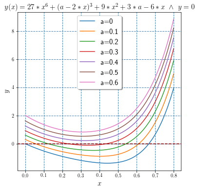

```python
def F(x,a): return 27 * x ** 6 + (a - 2 * x) ** 3 + 9 * x ** 2 + 3 * a - 6 * x
X = numpy.linspace(0, 0.8)

plt.figure(figsize=(6,6))
for a in [0, 0.1, 0.2, 0.3, 0.4, 0.5, 0.6]:
    plt.plot(X, [F(x,a) for x in X], label='a='+str(a))

plt.axhline(0, c='darkred', ls='--')
plt.legend(shadow=True, loc=9, fontsize=15)
plt.xlabel(r'$x$', fontsize=15)
plt.ylabel(r'$y$', fontsize=15)
plt.title(r'$y(x) = 27 * x^6 + (a - 2 * x)^3 + 9 * x^2 + 3 * a - 6 * x \ \land \ y = 0$', fontsize=15)
plt.grid(c='steelblue', ls='--', lw=1);
```

1)

Преобразования уравнения / Equation transformations

$27 * x^6 + (a - 2 * x)^3 + 9 * x^2 + 3 * a = 6 * x$

$27 * x^6 + 9 * x^2 = (2 * x - a)^3 + 6 * x - 3 * a$

$(3 * x^2)^3 + 3 * (3 * x^2) = (2 * x - a)^3 + 3 * (2 * x - a)$

2)

У функции вида $f(k) = k^3 + 3 * k$ производная $f'(k) = 3 * k^2 + 3$ положительна при любом значении переменной.

For еру function $f(k) = k^3 + 3 * k$, the derivative $f'(k) = 3 * k^2 + 3$ is positive for any value of the variable.

$\implies f(k)$ монотонно возрастает, каждому значению функции соответствует единственное значение аргумента.

$\implies f(k)$ is monotonically increasing, each value of the function corresponds to the single value of the argument.

$f(3 * x^2) = f(2 * x - a) \iff 3 * x^2 = 2 * x - a$

$3 * x^2 - 2 * x + a = 0$

3)

Квадратное уравнение не имеет корней, если его дискриминант меньше нуля.

A quadratic equation has no roots if its discriminant is less than zero.

$D = 2^2 - 4 * 3 * a = 4 - 12 *a$

$4 - 12 * a < 0 \iff a > \frac{1}{3}$

### Ответ / Answer: $(\frac{1}{3}; +\infty)$

```python
answer_dictionary[18] ='(1/3;+∞)'
```

[figure not shown]

### Задание 19 / Task 19

В результате опроса выяснилось, что примерно 54% опрошенных предпочитают искусственную елку натуральной

(число 54 получено с помощью округления до ближайшег целого числа).

а) Могло ли в опросе участвовать ровно 34 человека?

б) Могло ли в опросе участвовать менее 34 человек?

в) Какое наименьшее число человек могло участовать в опросе?

As a result of the poll, it was found out that approximately 54% of respondents prefer an artificial Christmas tree

(the number 54 is obtained by rounding to the nearest integer).

a) Could exactly 34 people participate in the survey?

b) Could the survey involve less than 34 people?

c) What is the smallest number of people who could participate in the survey?

а) нет

До 54 округляются все числа $x$ в интервале

$53.5 \leq x < 54.5 (*)$

Умножим неравенство $(*)$ на 34 и поделим на 100.

$18.19 \leq 34 * x / 100 < 18.53$

Количество предпочитающих искусственную елку респондентов должно быть целым числом.

В полученном интервале нет целых чисел, значит 34 человека участвовать в опросе не могло.

б) да

Умножим неравенство $(*)$ на любое из чисел 13, 24, 26, 28 и поделим на 100.

$12.84 \leq 24 * x / 100 < 13.08$

$13.91 \leq 26 * x / 100 < 14.17$

$14.98 \leq 28 * x / 100 < 15.26$

В каждый из полученных промежутков попадает одно целое число.

Оно составляет приблизительно 54% от общего числа участников опроса.

в) 13

### Ответ / Answer: а) нет; б) да; в) 13

```python
for a in range(0,100):
    if int(a*0.545) - int(a*0.535) > 0 :
        print(a, a*0.535, a*0.545)
```

```
13 6.955 7.085000000000001
24 12.84 13.080000000000002
26 13.91 14.170000000000002
28 14.98 15.260000000000002
35 18.725 19.075000000000003
37 19.795 20.165000000000003
39 20.865000000000002 21.255000000000003
41 21.935000000000002 22.345000000000002
46 24.610000000000003 25.07
48 25.68 26.160000000000004
50 26.75 27.250000000000004
52 27.82 28.340000000000003
54 28.89 29.430000000000003
56 29.96 30.520000000000003
57 30.495 31.065
```

[output cut: 32 more lines]

```python
answer_dictionary[19] ='а) нет; б) да; в) 13'
```

## Ответы / Answers

| 1 | 2 | 3 | 4 | 5 | 6 | 7 | 8 | 9 | 10 | 11 | 12 |
| --- | --- | --- | --- | --- | --- | --- | --- | --- | --- | --- | --- |
| 61.2 | 8 | 20 | 0.6 | 1.5 | 120 | 3 | 21 | 535 | 37 | 30 | 28 |

| 13 | 14 | 15 | 16 | 17 | 18 | 19 |
| --- | --- | --- | --- | --- | --- | --- |
| a) $\pm 2 * \pi* n \; \lor $ $\pm \arccos \frac{1}{6} \pm 2 * \pi * k;$ $ n,k \in \mathbb{N}$; б) $-2 * \pi ; $ $ -2 * \pi + arccos\frac{1}{6}$ | б) $\frac{1}{4}$ | $[0;log_2{3}]$ | б) $\sqrt{3}$ | 319500 | $(\frac{1}{3}; +\infty)$ | а) нет; б) да; в) 13 |

```python
answer_dictionary
```

```
{1: '61.2',
 2: '8',
 3: '20',
 4: '0.6',
 5: '1.5',
 6: '120',
 7: '3',
 8: '21',
 9: '535',
 10: '37',
 11: '30',
 12: '28',
 13: 'a)±2πn ∨ ±arccos(1/6)±2πk; n,k∈ℕ; б)−2π;−2π+arccos(1/6)',
 14: 'б) 1/4',
 15: '[0;log2(3)]',
 16: '√3',
 17: '319500',
 18: '(1/3;+∞)',
 19: 'а) нет; б) да; в) 13'}
```

[figure not shown]